[figure not shown]

# Bayesian modeling with PyMC3 and ArviZ

[figure not shown]

Córdoba 2018

### Bayesian Modeling *

[figure not shown]

* AKA Bayesian statistics, Probabilistic modeling, probabilistic programming, probabilistic machine learning...

### A Gaussian Model

[figure not shown]

## Why do we need software for Bayesian modeling?

**Bayesian modeling is conceptually *simple* :-)**

- (Data, Likelihood, Priors) ---Bayes' theorem--- > Posterior Distribution

**Bayesian modeling is mathematically difficult :-(**

- Only a small subset of interesting models can be solved analytically --> we must use numerical methods
- We need tools to define, solve, interpret and critize models

### Enter Probabilistic Programming

- It is all about abstracting the inference procedure and providing tools for transparent, easy and iterative model building
- Models are written in code and then *compiled* to get the posterior

> **The promise: clear separation of modeling and inference. Practitioners should focus on modeling, not *computational details***

## PyMC3: Probabilistic programming with Python

[figure not shown]

- Model building
  - A large collections of probability distributions
  - A clear and powerful syntax
  - Integration with the PyData-stack
- Inference
  - Markov Chain Monte Carlo
  - Variational Inference
- Computational backend:
  - Theano --> Speed, automatic differenciation, mathematical optimizations, GPU Support
  - PyMC4 will probably use [Tensorflow](https://medium.com/@pymc_devs/theano-tensorflow-and-the-future-of-pymc-6c9987bb19d5)

```
Auto-assigning NUTS sampler...
Initializing NUTS using jitter+adapt_diag...
Multiprocess sampling (2 chains in 2 jobs)
NUTS: [σ, μ]
```

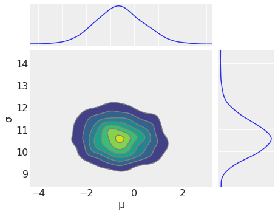

```python
with pm.Model() as modelo_g:
    μ = pm.Normal('μ', 0, 10)  # Prior
    σ = pm.HalfNormal('σ', 25)  # Prior
    y = pm.Normal('y', μ, σ, observed=data)  # Likelihood
    trace_g = pm.sample(1000)
az.plot_joint(trace_g, kind='kde', fill_last=False, textsize=16);
```

## Coal Mining Disasters

[figure not shown]

```
with pm.Model() as modelo_am:
    # Priors
    pc = pm.DiscreteUniform('pc', lower=years.min(), upper=years.max(), testval=1900)

    rate_0 = pm.Exponential('rate_0', 1)
    rate_1 = pm.Exponential('rate_1', 1)

    rates = pm.math.switch(pc >= years, rate_0, rate_1)
    # Likelihood
    dissasters = pm.Poisson('dissasters', rates, observed=data)
    # Inference
    trace_am = pm.sample(1000)
```

[figure not shown]

## Linear regression

```
with pm.Model() as linear_regression:
    # Priors
    α = pm.Normal('α', mu=0, sd=10)
    β = pm.Normal('β', mu=0, sd=1, shape=K)
    ϵ = pm.HalfNormal('ϵ', 10)
    μ = α + pm.math.dot(X, β) # linear model
    #Likelihood
    y_pred = pm.Normal('y_pred', mu=μ, sd=ϵ, observed=y_obs)
    # Inference
    trace = pm.Sample(1000)
```

## Hierarchical models

[figure not shown]

```
with pm.Model() as modelo_gh:
    # hyper-prior
    μ_μ = pm.Normal('μ_μ', 0, 10)
    σ_μ = pm.HalfNormal('σ_μ', 25)
    # Priors
    μ = pm.Normal('μ', μ_μ, σ_μ, shape=K)
    σ = pm.HalfNormal('σ', 25)
    # Likelihood
    y = pm.Normal('y', μ, σ, observed=data)
    # Inference
    trace_gh = pm.sample(1000)
```

[figure not shown]

## and many more...

[figure not shown]

[PyMC3 documentation](https://docs.pymc.io/)

## Hierarchical Bayesian neural networks

[figure not shown]

https://twiecki.github.io/blog/2018/08/13/hierarchical_bayesian_neural_network/

## Physical and statistical models

[figure not shown]

## ArviZ: Exploratory analysis of Bayesian models

[figure not shown]

- Includes numerical and visual functions for posterior analysis, sample diagnostics, model checking, and comparison.
- The goal is to provide backend-agnostic tools for exploratory analysis of Bayesian models in Python, by first converting inference data into [xarray](http://xarray.pydata.org/en/) objects.
- It is currently in heavy development (0.1.0 version released a week ago).

## Xarray

[figure not shown]

- N-dimensional labeled arrays and datasets in Python
- xarray.Dataset is an in-memory representation of a netCDF file

```python
inference_data = az.load_arviz_data('centered_eight')
inference_data
```

```
Inference data with groups:
	> posterior
	> sample_stats
	> posterior_predictive
	> prior
	> observed_data
```

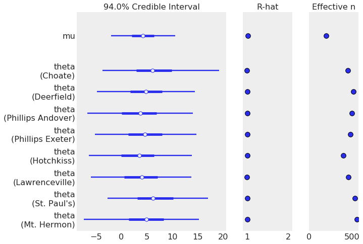

```python
az.plot_forest(inference_data, var_names=['mu', 'theta'], combined=True, figsize=(10, 8));
```

## Model Comparison

[figure not shown]

- WAIC: A way to approximate the generalization error. Measures model-fit and penalizes model complexity
- LOO: A way to approximate leave-one-out cross validation without re-fitting the model

## Model Comparison

- Model selection: Choose the model with lower WAIC/LOO

[figure not shown]

- Model averaging: Average models according to their values of WAIC/LOO

$$w_i = \frac {e^{ \frac{1}{2} dWAIC_i }} {\sum_j^M e^{ - \frac{1}{2} dWAIC_j }}$$

[figure not shown]

- Styles

  ```
  az.style.use('arviz-darkgrid')
  ```

- Support for PyMC3 and PyStan objects
- Python >= 3.4
- A unified datastructure for probabilistic programming?
- An opportunity to think deeper about Exploratory analysis of Bayesian models?

## PyMC and Arviz future

- Integrate Approximate Bayesian Computation (part of a GSoC)
- Discontinuous Hamiltonian Monte Carlo
- ODE solvers
- BARTS (Bayesian additive regression trees)
- Integrate ArviZ into PyMC3
- More than one ploting-backend for ArviZ (altair is a good candidate)
- Reach out to other libraries that may be interested to use ArviZ

[figure not shown]

- https://github.com/pymc-devs/resources

[figure not shown]

Image Markov Chain Monte Carlo https://github.com/ColCarroll/imcmc

## Stats-ML 2D plane (work in progress)

[figure not shown]